# NGP Wheat Farming Price and Precipitation Stress Analysis

In the code below, I document my process of analyzing historical stressors for large-scale wheat farms in the Northern Great Plains. Specifically, I want to know how resilient farmers are in the face of the common major stressors they face.

#### Hypothesis 1: The major driving stressors in large-scale agricultural systems are drought, and the nitrogen-to-wheat price ratio. Weed/pest pressure and spatial variability have a much lower economic impact on farms overall.

*(Answer using survey and interview data)*

#### Hypothesis 2: Farmers have become much less economically resilient and much more vulnerable to climatic changes since 1960.

- 2a: Farmers have become more reliant on external inputs. Thus, as prices for inputs and commodities have experienced greater fluctuations, the economic stability of farms has decreased. *(Historical Data)*
- 2b: Farmers currently have few options for moderating the effects of economic stressors (nitrogen-to-wheat price ratio) or the stress associated with unpredictable drought. *(Primarily survey, some interview)*

#### Hypothesis 3: Farmers have limited adaptability/adaptive capacity to the stressors listed above.

*(Interview)*

- 3a: What is the process by which farmers choose to alter their agronomic management (either proactive or reactive)?
- 3b: Use interview data to generate theory about the process of adaptation. *(Seeing risks -> Finding options -> Evaluating through value lens -> Detailed analysis via peer examples -> testing -> implementation)*
- 3c: What conclusions can be drawn about the adaptability of these more progressive farmers?

I hypothesize that as the time since stress increases, farmers become less concerned with adaptations to avoid that source of stress. For example, if there was a drought last year, farmers would be highly interested in alternative management strategies that could help them avoid the impacts of reduced moisture. As the time since that drought increased, they would become more and more complacent, perhaps focusing on other stressors that were more immediate (especially given their typical 1-2 yr planning time horizons).

With this knowledge, it would be possible both to understand the physical stressors that may drive adaptability, but also to take advantage of the associated psychological processes. If it had been a long time since a drought, but the N-wheat price ratio was relatively high, then trying to promote alternative management strategies with the stated goal of drought mitigation would be pointless. Instead, it would make more sense to emphasize the benefits of a practice such as crop rotation for the purpose of reducing N inputs, rather than as a water use minimization strategy.

The final part of this analysis is intended to feed into my assessment of resilience. How resilient are farmers to drought and changes in prices. Do they have many options available? If not (which appears to be the case), how could we promote the use of alternative crops/management that simultaneously fit our goals for sustainability? What would be the most effective avenues or information channels to promote those alternatives? This final bit gets into the sociological methods.

*The analysis was performed in Python, using the pandas and matplotlib packages*

## Hypothesis 1: The major driving stressors in large-scale agricultural systems are drought, and the nitrogen-to-wheat price ratio. Weed/pest pressure and spatial variability have a much lower economic impact on farms overall.

To answer this question, I will reference the survey data, interview data, historical USDA data, and census records. Note that the survey question below was not originally designed to answer this question. I will be asking follow-up questions related to weeds/spatial stressors in the upcoming round of interviews.

#### Question: Of the following extreme events that may have impacted your production, have you experienced them more frequently, less frequently, or no change?

```python
#Import the required libraries
import pandas as pd
```

```python
extremeEvents = pd.read_csv('C:/Users/patrick.lawrence.MSU/Documents/models/stress_analysis/survey_extreme_cleaned.csv',index_col='Respondent')
extremeEventsSum = pd.DataFrame([extremeEvents[extremeEvents == 2].sum(axis=0)/2/.51,extremeEvents[extremeEvents == 1].sum(axis=0)/.51,extremeEvents[extremeEvents == 0].count(axis=0)/.51])
```

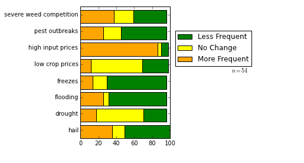

```python
fig=plt.figure(figsize=(6,4))
#ax=fig.add_axes([0.1, 0.1, .9, 0.75])
ax=subplot(121)
p1=ax.barh(arange(8),extremeEventsSum.ix[0].values,facecolor="orange")
p2=ax.barh(arange(8),extremeEventsSum.ix[1].values,facecolor="yellow",left=extremeEventsSum.ix[0])
p3=ax.barh(arange(8),extremeEventsSum.ix[2].values,facecolor="green",left=(extremeEventsSum.ix[0]+extremeEventsSum.ix[1]))
yticks(arange(0.5,8.5,1),extremeEventsSum.columns,rotation=0)
ax2=subplot(122)
axis('off')
box=ax2.get_position()
ax2.set_position([box.x0, box.y0, box.width*1.2, box.height*1])
fig.legend(loc="upper right",labels=("Less Frequent","No Change","More Frequent"),handles=(p3[3],p2[2],p1[1]),bbox_to_anchor=(1,.8))
plot_margin=0.5
plt.annotate('n = 54', xy=(2, 1), xytext=(3, 1.5))
text(0.4, .5, r'$n=54$')
```

So as we can see, more frequent high input prices are by and large the biggest concern for producers. Severe weed competition is perceived to be equally less frequent and more frequent. Furthermore, out of ten farmers inteviewed, only one mentioned it as a criterion for decision-making. Interestingly, drought is not perceived to be more frequent.

#### Question: How do you balance new crops or management in terms of economic profit, environmental sustainability and amount of effort required?

> Response 1: Very first question we are going to look at is can we make this crop break even? If that answer is yes then we’ll start asking if this crop will do better than break even, what are the grosses and nets on this crop. After that, agronomic sustainability. ....And from there I start looking at how much work there will be for this crop. We look at some of that and we figure out what quirks or idiosyncrasies they might have at the planning level and or at the weed control/ crop protection window or the harvest window or even at a marketing window.

However, weeds are very infrequently mentioned, and topographic/spatial variability is *never* mentioned at all. In my next round of questioning, I will ask several questions to verify the scope of influence of these variables both as sources of stress and as drivers of decision-making.

## Hypothesis 2: Farmers have become much less economically resilient and much more vulnerable to climatic changes since 1960.

- **2a: Farmers have become more reliant on external inputs. Thus, as prices for inputs and commodities have experienced greater fluctuations, the economic stability of farms has decreased.**

To perform the analysis, I draw upon wheat and Nitrogen price data from the USDA, Palmer z-index (a drought index) data from the National Climatic Data Center (NCDC), and census data from the USDA National Ag Statistics Service (NASS). Since two of the major inputs into dryland wheat production systems are N (controlled), and precipitation (uncontrolled), it would be useful to know how these two factors influence the decision-making, adaptability, and willingness to experiment of farmers.

Load the data files. Note that I originally used pdsi instead of the palmer z-index, hence pdsi is the name of the dataframe, even though I am using a different index (Z-index is more correlated to yields - Quiring(2003)).

```python
nPrices = pd.read_csv('C:/Users/patrick.lawrence.MSU/Documents/models/stress_analysis/nPrices_cleaned.csv',index_col='Year')
wPrices = pd.read_csv('C:/Users/patrick.lawrence.MSU/Documents/models/stress_analysis/wPrices_cleaned.csv',index_col='mkt_yr')
pzi = pd.read_csv('C:/Users/patrick.lawrence.MSU/Documents/models/stress_analysis/palmer_z_cleaned.csv')
```

First, we need to remove white space in the month data field for the fertilizer dataset.

```python
nPrices['Month'] = nPrices['Month'].apply(lambda x: x.strip(' '))
```

With the data files loaded, now we want to convert the fertilizer prices from dollars per lb to dollars per short ton to dollars per kg. Furthermore, we should probably be using the April or March fertilizer prices (as opposed to September) when available since that is more likely to be the time when farmers purchase fertilizer. We also want to convert wheat prices from dollars per bushel to dollars per kg. Note that we'll just use the average yearly HRWW prices for now (may want to change later).

```python
nPrices = nPrices[nPrices['Month'].isin(['Apr.','Mar.'])]
```

```python
nPrices['Urea_Price'] = nPrices['Urea_Price']/907.185
nPrices['AN_Price'] = nPrices['AN_Price']/907.185
nPrices['AS_Price'] = nPrices['AS_Price']/907.185
nPrices['Anhydrous_Price'] = nPrices['Anhydrous_Price']/907.185
wPrices['HRWW_Avg'] = wPrices['HRWW_Avg']/27.2155
```

We also need to average the Palmer Z-Index data in some respect for each year. Let's try averaging the PZI for the primary growing season, April through August (can change later).

```python
#Replace values of -99.999999 with null
pzi[pzi<-50] = NaN
Avg = pd.Series([pzi.ix[x,"Apr":"Aug"].mean(axis=1,skipna=True) for x in pzi.index],name="Avg")
```

```python
pzi['Avg'] = Avg
```

Mext we calculate the ratio of the price of Urea to the price of wheat.

```python
nwpriceratio = nPrices['Urea_Price']/wPrices.ix['1960/61':,'HRWW_Avg'].values
```

```python
wPrices.ix['1960/61':,'HRWW_Avg'].head()
```

```
mkt_yr
1960/61    0.064302
1961/62    0.066874
1962/63    0.073855
1963/64    0.070181
1964/65    0.051441
Name: HRWW_Avg, dtype: float64
```

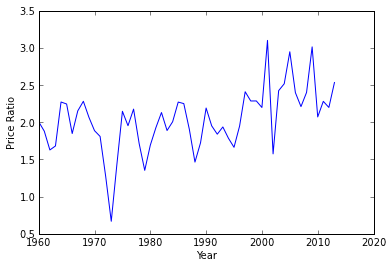

```python
plot(nPrices.index,nwpriceratio)
xlabel("Year")
ylabel("Price Ratio")
```

Ok, now let's calculate deviations from the average to see how far the N/W price ratio and how far the pdsi have gone astray. Remember that negative values for PDSI imply greater drought.

```python
pzideviations = (pzi.Avg-mean(pzi.Avg))/std(pzi.Avg)
pzi['dev'] = pzideviations
nwprdeviations = (nwpriceratio-nwpriceratio.mean())/std(nwpriceratio)
nwpriceratio = pd.DataFrame(nwpriceratio,columns=['ratio'])
nwpriceratio['dev'] = nwprdeviations
```

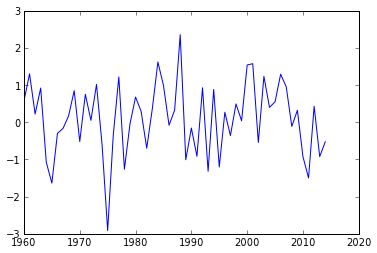

```python
plot(pzi['Year'][65:],-pzi['dev'][65:])
```

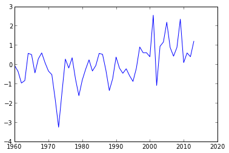

```python
plot(nPrices.index,nwpriceratio['dev'])
```

Ok, now let's try seeing the cumulative effects in a simplistic, additive fashion. Note that the pdsi values need to be reversed to make sense. In this case, the more positive = the more stress.

```python
totalstress = -pzi[pzi['Year']>=1960][:-1]['dev'].values+nwpriceratio['dev'].values
#totalstress.reset_index(arange(1960,2014),drop=True,name='dev')
totalstress = pd.Series(totalstress,index=arange(1960,2014))
```

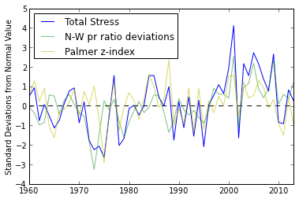

```python
plot(totalstress.index,totalstress,label="Total Stress")
plot(nPrices.index,nwpriceratio['dev'],'-g',alpha=.5,label="N-W pr ratio deviations")
plot(pzi['Year'][65:],-pzi['dev'][65:],'-y',alpha=.6,label="Palmer z-index")
xlim(1960,2013)
hlines(0,1960,2020,linestyles='dashed')
ylabel("Standard Deviations from Normal Value")
legend(loc='upper left')
```

Note: Just to check, I plotted the palmer z-index against my growing season precip data from Sun River, and they seem to match up reasonably well, which is encouraging. I wouldn't expect full correspondence, since the z-index is for the whole of region 3 (approx. the NGP in Montana). See Quiring (2003) in Ag and Forest Meteorology for why I used the z-index.

In order to place the impact of the N-Wheat price ratio deviations into context, it would be helpful to know the average farmers' dependence on [exposure to] N, relative to the total yields on their farm. If their dependence on N is high, this would have a lower impact for smaller acreages than larger acreages. A smaller-scale farmer would have the same relative exposure on a per-acre basis, but a much lower exposure over the entire farm acreage.

To get a handle on this, we need to know average farm size, and the quantity of N applied per acre. We will assume that yields do not vary much by farm size. Obviously, the data probably don't exist to assess the amounts of applied N per acre by farm size. However, we're more interested in average exposures to N-Wheat price ratio fluctuations, so averages may be sufficient.

Let's start by examining farm sizes (for small-grains farms), as those are the most straightforward data.

```python
censusdata = pd.read_csv('C:/Users/patrick.lawrence.MSU/Documents/models/stress_analysis/census_cleaned.csv',index_col='Year')
```

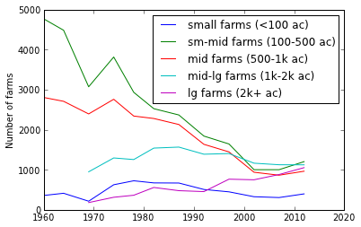

```python
plot(censusdata.index,censusdata.FS_1_49+censusdata.FS_50_99,label="small farms (<100 ac)")
plot(censusdata.index,censusdata.FS_100_199+censusdata.FS_200_499,label="sm-mid farms (100-500 ac)")
plot(censusdata.index,censusdata.FS_500_999,label="mid farms (500-1k ac)")
plot(censusdata.index,censusdata.FS_1000_1999,label="mid-lg farms (1k-2k ac)")
plot(censusdata.index,censusdata.FS_gt_2000,label="lg farms (2k+ ac)")
ylabel("Number of farms")
legend(loc="upper right")
```

It appears that while there has been an uptick in all farms (aside from mid-large) from 2005 to 2010, the overarching trend since 1960 has been for a decline in the number of small-mid and mid-size farms, and an increase in the number of large farms (mid-large have remained constant).

For fertilizer data, I will first assimilate data from Rick Engle on the amount of fertilizer used by year (Across all crops) since 1970. We will bring in the Ammonium Nitrate, Ammonium Sulfate, Anhydrous NH3 and Urea quantities applied over ALL cropped acres (assuming most are in small grains). Initial units are thousands of MT (Metric Tons; for the entire state).

```python
nQuantity = pd.read_csv('C:/Users/patrick.lawrence.MSU/Documents/models/stress_analysis/nQuantity_cleaned.csv',index_col='Year')
```

First, I will display the evolution of N use by type from 1970 onwards.

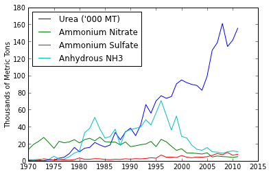

```python
plot(nQuantity.index,nQuantity.Urea_MT,label="Urea ('000 MT)")
plot(nQuantity.index,nQuantity.AN_MT,label="Ammonium Nitrate")
plot(nQuantity.index,nQuantity.AS_MT,label="Ammonium Sulfate")
plot(nQuantity.index,nQuantity.Anhydrous_MT,label="Anhydrous NH3")
ylabel("Thousands of Metric Tons")
legend(loc="upper left")
```

From these fertilizer data, we then need to know the amount of applied product per acre. Thus we will need to divide the total fertilizer quantities by the total number of small grains acres. Note - switching '000 MT to kg requires multiplication by 1 million. **NOTE: I will temporarily substitute 2011 data for 2012 for fertilizer usage in order to extend the analysis.**

```python
temp_peracre = pd.DataFrame({'Urea_acre':(nQuantity.Urea_MT*1000000/censusdata.cg_cropland_farms).dropna(),'AN_acre':(nQuantity.AN_MT*1000000/censusdata.cg_cropland_farms).dropna(),
                            'AS_acre':(nQuantity.AS_MT*1000000/censusdata.cg_cropland_farms).dropna(),'Anhydrous_acre':(nQuantity.Anhydrous_MT*1000000/censusdata.cg_cropland_farms).dropna()})
#temp_peracre.columns = ['Urea_acre','AN_acre','AS_acre','Anhydrous_acre']
censusdata = pd.merge(censusdata,temp_peracre,left_index=True,right_index=True,how='outer')
censusdata.ix[2012,'Urea_acre'] = nQuantity.Urea_MT.ix[2011]*1000000/censusdata.ix[2012,'cg_cropland_farms']
censusdata.ix[2012,'AN_acre'] = nQuantity.AN_MT.ix[2011]*1000000/censusdata.ix[2012,'cg_cropland_farms']
censusdata.ix[2012,'AS_acre'] = nQuantity.AS_MT.ix[2011]*1000000/censusdata.ix[2012,'cg_cropland_farms']
censusdata.ix[2012,'Anhydrous_acre'] = nQuantity.Anhydrous_MT.ix[2011]*1000000/censusdata.ix[2012,'cg_cropland_farms']
```

Let's take a quick look at the per acre usage.

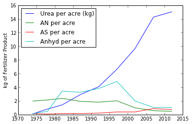

```python
plot(censusdata.index,censusdata.Urea_acre,label="Urea per acre (kg)")
plot(censusdata.index,censusdata.AN_acre,label="AN per acre")
plot(censusdata.index,censusdata.AS_acre,label="AS per acre")
plot(censusdata.index,censusdata.Anhydrous_acre,label="Anhyd per acre")
ylabel("kg of Fertilizer Product")
legend(loc="upper left")
```

These numbers seem low, if anything. This will require some cross-checking for validation.

Now that we have the kg/acre of each product, we can calculate the amount of each product for each class of farm (using the size mid-points for now). Note that I'm keeping the fert types separate now due to different historical prices.

```python
censusdata['smallQ_urea'] = censusdata.Urea_acre*50
censusdata['smmidQ_urea'] = censusdata.Urea_acre*300
censusdata['midQ_urea'] = censusdata.Urea_acre*750
censusdata['midlgQ_urea'] = censusdata.Urea_acre*1500
censusdata['lgQ_urea'] = censusdata.Urea_acre*3000
censusdata['smallQ_AN'] = censusdata.AN_acre*50
censusdata['smmidQ_AN'] = censusdata.AN_acre*300
censusdata['midQ_AN'] = censusdata.AN_acre*750
censusdata['midlgQ_AN'] = censusdata.AN_acre*1500
censusdata['lgQ_AN'] = censusdata.AN_acre*3000
censusdata['smallQ_AS'] = censusdata.AS_acre*50
censusdata['smmidQ_AS'] = censusdata.AS_acre*300
censusdata['midQ_AS'] = censusdata.AS_acre*750
censusdata['midlgQ_AS'] = censusdata.AS_acre*1500
censusdata['lgQ_AS'] = censusdata.AS_acre*3000
censusdata['smallQ_Anhydrous'] = censusdata.Anhydrous_acre*50
censusdata['smmidQ_Anhydrous'] = censusdata.Anhydrous_acre*300
censusdata['midQ_Anhydrous'] = censusdata.Anhydrous_acre*750
censusdata['midlgQ_Anhydrous'] = censusdata.Anhydrous_acre*1500
censusdata['lgQ_Anhydrous'] = censusdata.Anhydrous_acre*3000
```

Now we can calculate the entire exposure per farm size class, with the different fert historical prices factored in.

```python
nPrices.index=range(1960,2014)
censusdata['smallQ_exp'] = censusdata.smallQ_urea*nPrices.Urea_Price + censusdata.smallQ_AN*nPrices.AN_Price + censusdata.smallQ_AS*nPrices.AS_Price + censusdata.smallQ_Anhydrous*nPrices.Anhydrous_Price
censusdata['smmidQ_exp'] = censusdata.smmidQ_urea*nPrices.Urea_Price + censusdata.smmidQ_AN*nPrices.AN_Price + censusdata.smmidQ_AS*nPrices.AS_Price + censusdata.smmidQ_Anhydrous*nPrices.Anhydrous_Price
censusdata['midQ_exp'] = censusdata.midQ_urea*nPrices.Urea_Price + censusdata.midQ_AN*nPrices.AN_Price + censusdata.midQ_AS*nPrices.AS_Price + censusdata.midQ_Anhydrous*nPrices.Anhydrous_Price
censusdata['midlgQ_exp'] = censusdata.midlgQ_urea*nPrices.Urea_Price + censusdata.midlgQ_AN*nPrices.AN_Price + censusdata.midlgQ_AS*nPrices.AS_Price + censusdata.midlgQ_Anhydrous*nPrices.Anhydrous_Price
censusdata['lgQ_exp'] = censusdata.lgQ_urea*nPrices.Urea_Price + censusdata.lgQ_AN*nPrices.AN_Price + censusdata.lgQ_AS*nPrices.AS_Price + censusdata.lgQ_Anhydrous*nPrices.Anhydrous_Price
```

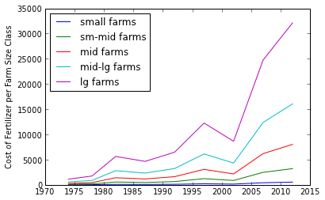

```python
plot(censusdata.index,censusdata.smallQ_exp,label="small farms")
plot(censusdata.index,censusdata.smmidQ_exp,label="sm-mid farms")
plot(censusdata.index,censusdata.midQ_exp,label="mid farms")
plot(censusdata.index,censusdata.midlgQ_exp,label="mid-lg farms")
plot(censusdata.index,censusdata.lgQ_exp,label="lg farms")
ylabel("Cost of Fertilizer per Farm Size Class")
legend(loc="upper left")
```

Ok, so while it's clear that large farm gross exposure is much higher, it may still be appropriate to concentrate the per-acre costs, since incorporating a whole net return function for different sizes of farms would introduce unnecessary complications. Furthermore, we are ultimately interested in the average farmer's exposure to unusual N-wheat price ratios, which could be deduced from a simple per-acre measure. Therefore, let's calculate the per-acre costs, incorporating historical price changes.

```python
censusdata['Total_Cost_Acre'] = censusdata.Urea_acre*nPrices.Urea_Price + censusdata.AN_acre*nPrices.AN_Price + censusdata.AS_acre*nPrices.AS_Price + censusdata.Anhydrous_acre*nPrices.Anhydrous_Price
```

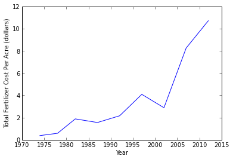

```python
plot(censusdata.index,censusdata.Total_Cost_Acre)
xlabel("Year")
ylabel("Total Fertilizer Cost Per Acre (dollars)")
```

This measure of economic stress is much more appropriate than the previous one, since it incorporates the changing mix of fertilizers used on farms, the quantity of those fertilizers used, and the differential prices of those fertilizers. What happens if we again perform our simplistic additive stress analysis?

```python
wPricesSample = [wPrices.ix['1974/75','HRWW_Avg'],wPrices.ix['1978/79','HRWW_Avg'],wPrices.ix['1982/83','HRWW_Avg'],
                 wPrices.ix['1987/88','HRWW_Avg'],wPrices.ix['1992/93','HRWW_Avg'],wPrices.ix['1997/98','HRWW_Avg'],
                 wPrices.ix['2002/03','HRWW_Avg'],wPrices.ix['2007/08','HRWW_Avg'],wPrices.ix['2012/13','HRWW_Avg']]
censusdata['Total_Cost_Acre_Ratio'] = censusdata.Total_Cost_Acre.dropna()/wPricesSample
```

```python
censusdata['Total_Cost_Acre_Ratio_dev'] = (censusdata.Total_Cost_Acre_Ratio - censusdata.Total_Cost_Acre_Ratio.mean())/std(censusdata.Total_Cost_Acre_Ratio)
```

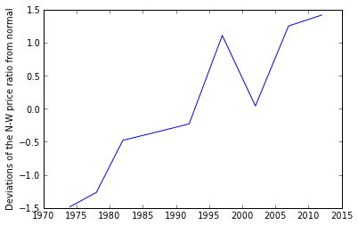

```python
plot(censusdata.index,censusdata.Total_Cost_Acre_Ratio_dev)
ylabel("Deviations of the N-W price ratio from normal")
```

```python
pziclip = [-pzi.ix[79,'dev'],-pzi.ix[83,'dev'],-pzi.ix[82,'dev'],-pzi.ix[87,'dev'],
           -pzi.ix[92,'dev'],-pzi.ix[97,'dev'],-pzi.ix[02,'dev'],-pzi.ix[07,'dev'],-pzi.ix[12,'dev']]
totalstress_updated = pziclip+censusdata.Total_Cost_Acre_Ratio_dev.dropna()
#totalstress.reset_index(arange(1960,2014),drop=True,name='dev')
#totalstress = pd.Series(totalstress,index=arange(1960,2014))
```

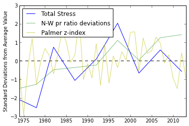

```python
plot(totalstress_updated.index,totalstress_updated,label="Total Stress")
plot(censusdata.index,censusdata.Total_Cost_Acre_Ratio_dev,'-g',alpha=.5,label="N-W pr ratio deviations")
plot(pzi['Year'][65:],-pzi['dev'][65:],'-y',alpha=.6,label="Palmer z-index")
xlim(1974,2013)
hlines(0,1974,2020,linestyles='dashed')
ylabel("Standard Deviations from Average Value")
legend(loc='upper left')
```

The downside to using the census data is of course a much lower resolution picture of the price stressors, but during those years when we have data it is likely more a more accurate representation of the economic stressors (which seem to be increasing).

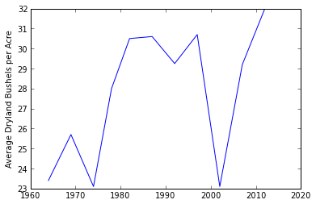

```python
plot(censusdata.index,censusdata.bu_ac_avg)
ylabel("Average Dryland Bushels per Acre")
```

### Hypothesis 2b: Farmers currently have few options for moderating the effects of economic stressors (nitrogen-to-wheat price ratio) or the stress associated with unpredictable drought.

To answer this question, we will first look at the survey data. Note that I have only asked questions regarding drought and still need to ask about options for dealing with high input prices (relative to wheat prices).

#### Question: If in the future precipitation were to decrease significantly for 10 years, how many new crops would you sow on your farm to adapt to the drought?

```python
noAltCrops = pd.read_csv('C:/Users/patrick.lawrence.MSU/Documents/models/stress_analysis/survey_numcrops_cleaned.csv')
```

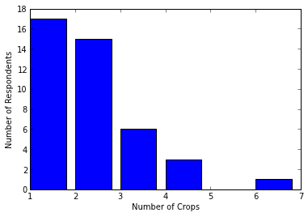

```python
fig=figure()
ax = subplot(111)
ax.bar(noAltCrops.No_Crops,noAltCrops.Respondents)
ylabel("Number of Respondents")
xlabel("Number of Crops")
#xticks(arange(0.5,25,1),AltCrops.Crop,rotation=90)
```

#### Question: What crops would you choose?

```python
AltCrops = pd.read_csv('C:/Users/patrick.lawrence.MSU/Documents/models/stress_analysis/survey_no_alt_crops_cleaned.csv')
```

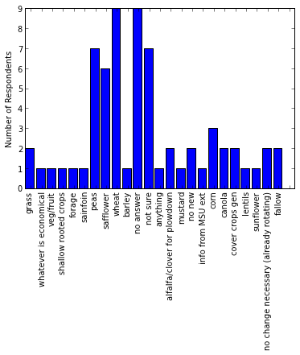

```python
fig=figure()
ax = subplot(111)
ax.bar(AltCrops.index,AltCrops.Respondents)
xticks(arange(0.5,25,1),AltCrops.Crop,rotation=90)
ylabel("Number of Respondents")
```

#### Question: In the above scenario, what other management practices would you change on your farm to adapt?

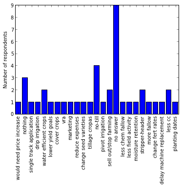

```python
altMgmt = pd.read_csv('C:/Users/patrick.lawrence.MSU/Documents/models/stress_analysis/survey_alt_practices_cleaned.csv')
fig=figure()
ax = subplot(111)
ax.bar(altMgmt.index,altMgmt.Respondents)
xticks(arange(0.5,25,1),altMgmt.alternative_practice,rotation=90)
ylabel("Number of respondents")
```

Do the interviews back this up?

#### Question: What changing conditions do you feel like you’ve responded to already?

> Farmer 7: Already? Well the biggest change I’ve had to and still am responding to is drought! You know, nothing works anymore because we don’t get any rain. It’s really frustrating because all you do should be successful and when it doesn’t rain it doesn’t work. That’s pretty much out of our hands as to what we can do.

#### Interviewer: Well it sounds like you’re working on some new things to try to deal with that.

> Farmer 7: Yea I just raise dry land crops like dry land peas and they work great but not because you (can buy a bushel of peas? 5:17 ) it just doesn’t work economically. So I’ve been raising dry land crops for the last 5 or 6 years because it’s so dry.

#### Question: Do you feel like you are responding to changing conditions like drought or high input prices or are you trying to anticipate those so that you can be prepared?

> Farmer 9: We generally plan for a normal year. I mean, we don’t go for the extreme.

> Farmer 10: Well the input cost isn’t such a concern you know, it is what it is. We try to raise our crops when we can make a large production but season is somewhat different because we are not in control of the value of that crop and what we get for it. And we don’t change our rotation based on inputs too much. I mean we already know which crops can grow profitably and it depends on the size of the crop to the price of the product and you don’t have a whole lot of control over that.

#### Question: So you kind of do what you do anyway and let that be what it is?

> Yea, to some degree. We’re not going to keep growing a crop that’s not profitable where the inputs are so high that there’s no margin. Nobody can stay in business doing that but you don’t chase it around because it seems like you’ll never be right on that.

#### Question: Do you feel that with trying new things you are responding to changing conditions like drought or high-input prices or are you trying new practices in advance so that you’re prepared?

> It’s hard to, you know, think of anything that’s out there, research-wise, to help you through a drought, but if you can have conversations and if you have friends help you, they’re going to help you out right back.

### Conclusion - Hypothesis 2b.

Farmers appear to have limited options for responding to drought.

### Hypothesis 2c: Farmers utilize only a limited number of information sources for learning about agronomic alternatives that would increase their adaptability.

#### Question: 9. What type and sources (people or otherwise) would you turn to for guidance on farming matters if you weren’t sure how to deal with decreased precipitation? Rate the following sources (by ticking a box) where 1 indicates you wouldn’t use the source at all and 10 indicates you would definitely consult the source.

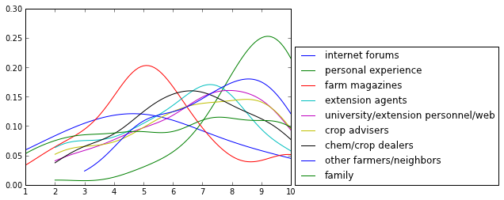

```python
from sklearn.neighbors.kde import KernelDensity
survey_sources = pd.read_csv('C:/Users/patrick.lawrence.MSU/Documents/models/stress_analysis/survey_sources_cleaned.csv')

#age = titanic.age.dropna().values  # drop missing values, turn to normal numpy array
internet = survey_sources.ix[0,arange(1,53)].dropna()
internet = internet.reshape(-1, 1)  # scikit-learn expects data matrices of shape [ndata, ndim]
personal = survey_sources.ix[8,arange(1,53)].dropna()
personal = personal.reshape(-1, 1)
farmmags = survey_sources.ix[1,arange(1,53)].dropna()
farmmags = farmmags.reshape(-1, 1)
extagents = survey_sources.ix[2,arange(1,53)].dropna()
extagents = extagents.reshape(-1, 1)
university = survey_sources.ix[3,arange(1,53)].dropna()
university = university.reshape(-1, 1)
cropadv = survey_sources.ix[4,arange(1,53)].dropna()
cropadv = cropadv.reshape(-1, 1)
chem = survey_sources.ix[5,arange(1,53)].dropna()
chem = chem.reshape(-1, 1)
otherfarmers = survey_sources.ix[6,arange(1,53)].dropna()
otherfarmers = otherfarmers.reshape(-1,1)
family = survey_sources.ix[7,arange(1,53)].dropna()
family = family.reshape(-1,1)


kde = KernelDensity(bandwidth=2).fit(internet)
kde2 = KernelDensity(bandwidth=1).fit(personal)
kde3 = KernelDensity(bandwidth=1).fit(farmmags)
kde4 = KernelDensity(bandwidth=1).fit(extagents)
kde5 = KernelDensity(bandwidth=1).fit(university)
kde6 = KernelDensity(bandwidth=1).fit(cropadv)
kde7 = KernelDensity(bandwidth=1).fit(chem)
kde8 = KernelDensity(bandwidth=1).fit(otherfarmers)
kde9 = KernelDensity(bandwidth=1).fit(family)
x = np.linspace(internet.min(), internet.max(), 100).reshape(-1, 1)
x2 = np.linspace(personal.min(), personal.max(), 100).reshape(-1, 1)
x3 = np.linspace(farmmags.min(), farmmags.max(), 100).reshape(-1, 1)
x4 = np.linspace(extagents.min(), extagents.max(), 100).reshape(-1, 1)
x5 = np.linspace(university.min(), university.max(), 100).reshape(-1, 1)
x6 = np.linspace(cropadv.min(), cropadv.max(), 100).reshape(-1, 1)
x7 = np.linspace(chem.min(), chem.max(), 100).reshape(-1, 1)
x8 = np.linspace(otherfarmers.min(), otherfarmers.max(), 100).reshape(-1, 1)
x9 = np.linspace(family.min(), family.max(), 100).reshape(-1, 1)
density = np.exp(kde.score_samples(x))
density2 = np.exp(kde2.score_samples(x2))
density3 = np.exp(kde3.score_samples(x3))
density4 = np.exp(kde4.score_samples(x4))
density5 = np.exp(kde5.score_samples(x5))
density6 = np.exp(kde6.score_samples(x6))
density7 = np.exp(kde7.score_samples(x7))
density8 = np.exp(kde8.score_samples(x8))
density9 = np.exp(kde9.score_samples(x9))

plt.plot(x, density,label="internet forums")
plt.plot(x2,density2,label="personal experience")
plt.plot(x3,density3,label="farm magazines")
plt.plot(x4,density4,label="extension agents")
plt.plot(x5,density5,label="university/extension personnel/web")
plt.plot(x6,density6,label="crop advisers")
plt.plot(x7,density7,label="chem/crop dealers")
plt.plot(x8,density8,label="other farmers/neighbors")
plt.plot(x9,density9,label="family")
legend(loc="upper right",bbox_to_anchor=(1.8,.81))
#plt.plot(age, age * 0, 'ok', alpha=.03)
```

#### And here are the average values:

```python
survey_sources.sort('Avg')[['Source','Avg']]
```

|  | Source | Avg |
| --- | --- | --- |
| 0 | internet forums | 5.224490 |
| 1 | farm mags | 5.437500 |
| 7 | family | 6.100000 |
| 2 | ext agents | 6.224490 |
| 5 | chem/crop dealers | 6.557692 |
| 4 | crop advisers | 6.653846 |
| 3 | university/ext personnel/web | 6.788462 |
| 6 | other farmers/neighbors | 7.450980 |
| 8 | personal experience | 8.568627 |

Note: will add some codes and/or responses here

### Farmer 9:

#### Question: Where do you usually go first for information on new agronomic practices? It sounds like with chemicals you often go to dealers but how about other things?

> I go to a lot of grower meetings and chemical meetings in the area, you know to get certified for your chemical plants and licenses. (I’m friends with most of the providers in the chemical industry? 5:11). And every now and then you’ll hear about something new that’s coming out from one of them and if I’m having some wheat problem, by god, I’m not afraid to volunteer and try a little pesticide.

#### How does that process work, experimenting? Where do you find out about those things first?

> Some from magazines, some from phone calls, people wanting to try different stuff, you know, like trying different chemicals. And then they come down and out a test plot on it and you get to see if the chemical worked or if it didn’t. That (spares? 2:30) us with other chemicals you know? Because it supposed to be doing the same thing. But some do, some don’t.

### Farmer 10:

#### Question: Where do you go first for information on new agronomic practices?

> Basically it’s from a lot of trade shows and I know a few scientists that I talk to. But basically, if it’s something we think we can do we start our own testing right here.

### Farmer 1:

#### Question: Where do you currently go first for information on new agronomic practices…other farmers or experimentations or other places?

> Well mainly other farmers and (the extension?) and the experimentations and what not.

### Farmer 2:

#### Question: Where do you currently go first for information on new agronomic practices like other farmers or experiment stations or other places?

> I’m probably going to say the research centers at MSU and NDSU, because we are kind of unique in this little corner since we have both states to go off on. So most of my information primarily comes from research centers and the research papers that are printed by the two universities.

### Farmer 3:

#### Question: Where do you currently go first for information on new agronomic practices? Farmers, experiment stations or other places?

> Well there’s always the internet first.

#### Question: And then after that, where do you tend to go?

> Well I try to find things from neighbors, we have some really great farms around here. The internet, then find out who you know.

#### Question: People who may have tried it or has some idea?

> Yea, and the more that I get to know the people at the college and the extension the more I go to them. The biggest problem we have with extensions here are that we have a little different climate and there’s really not an extension that matches it so we have a hard time finding the right information. So you can use the extensions but it wouldn’t necessarily translate because we are kind of in a weird area for that.

### Farmer 4:

#### Question: Can you describe your process of experimentation and decision-making about trying something new including taking risks with new crops?

> I do a lot of reading from different farm publications and I talk a lot with other people in the industry. I’m always trying to pick people’s brains. And I’ve been pretty fortunate I’ve had the opportunity to talk with some successful farmers that have been doing it longer than I have and kind of have the same philosophy. They haven’t been shy about giving me their secrets either.

#### Question: Where do you currently go first for information on new agronomic practices like other farmers or experiment stations or other places?

> I always check out experiment stations and different farming publications. Just talking to farmers and networking with people who have been there and done that.

## Section III: Questions to ask during new interviews:

1. How much impact do you think *_* (stressor) has on your bottom line? How much does it impact your management strategy?
2. How much does this factor vary on your farm?
3. What options do you have for dealing with this factor?
4. Would *_* (diversified practice) be a viable mgmt. practice to manage this uncertainty? **Diversification practice/homogenization
5. Do you feel like when this factor is worse, it restricts your agronomic management options? Does it limit your willingness to experiment?
6. In choosing those options, are you trying to reduce the amount of variability? Is this feasible?
7. How long has it been since you experienced high input prices/low wheat prices, weeds, drought? Do you feel like when this factor is less pressing, you don’t need to try as actively to find ways to work around it?
8. How much does this factor influence the new practices you’re experimenting with?
9. Why haven’t you tried cover cropping? Putting more crops in rotation? - rephrase to be less confrontational.

# Don't forget about crop insurance!!!!

#### Question: How do you decide to try something new?

> Response 1: Well I think when I see issues or problems with our current practice. And I can remember back in the 90’s dealing with a lot of wild oat problem and trying to put a pulse crop in the rotation to try and use the chemistry against the wild oat.

> Response 2: When someone comes up with something that makes it not only worthwhile economically but will help in the association to clean up weed problems in terms of crop rotation.

#### Despite this, at least some farmers do try new agronomic practices (rotations) for the purposes of pest/weed control.

> Response: Now it seems like they’re having more success in Northeastern Montana with rotations of peas and lentils and those types of crops to break the sawfly cycle. That seems to be working, so that’s one thing I want to get into is the peas and lentils to try and break the sawflies’ cycle.